# FlightAnalysis

Kevin Hutchins

10/1/2021

## What time of day should you fly if you want to avoid delays as much as possible?

I created a graph that groups the data by their scheduled departure times and compares their average delays.The scheduled departure time of each flight is in 24 hour time. From this graph, it seems that you want to get a flight as early as possible and avoid ~7 pm, as that is the time with the longest departure delays.

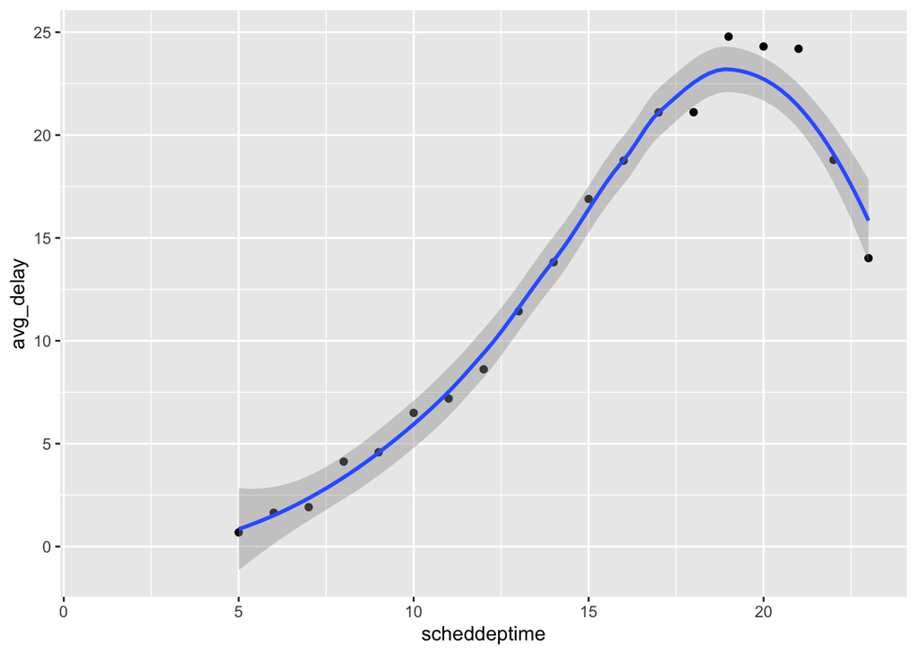

```r
data = mutate(flights, scheddeptime = ((sched_dep_time - (sched_dep_time %% 100)) * 0.01)) %>% relocate(scheddeptime, .after = sched_dep_time)
plotting = data %>% group_by(scheddeptime) %>% summarize(avg_delay = mean(dep_delay, na.rm = T), num = n())

p <- ggplot(data = plotting,
            mapping = aes(x = scheddeptime,
                          y = avg_delay))
p + geom_point() + geom_smooth()
```

##Does that hour depend on airline?

Note: not all airlines were placed on the graph. These airlines were chosen because they had over 1000 flights in the data. Any airline with less than that was ignored.

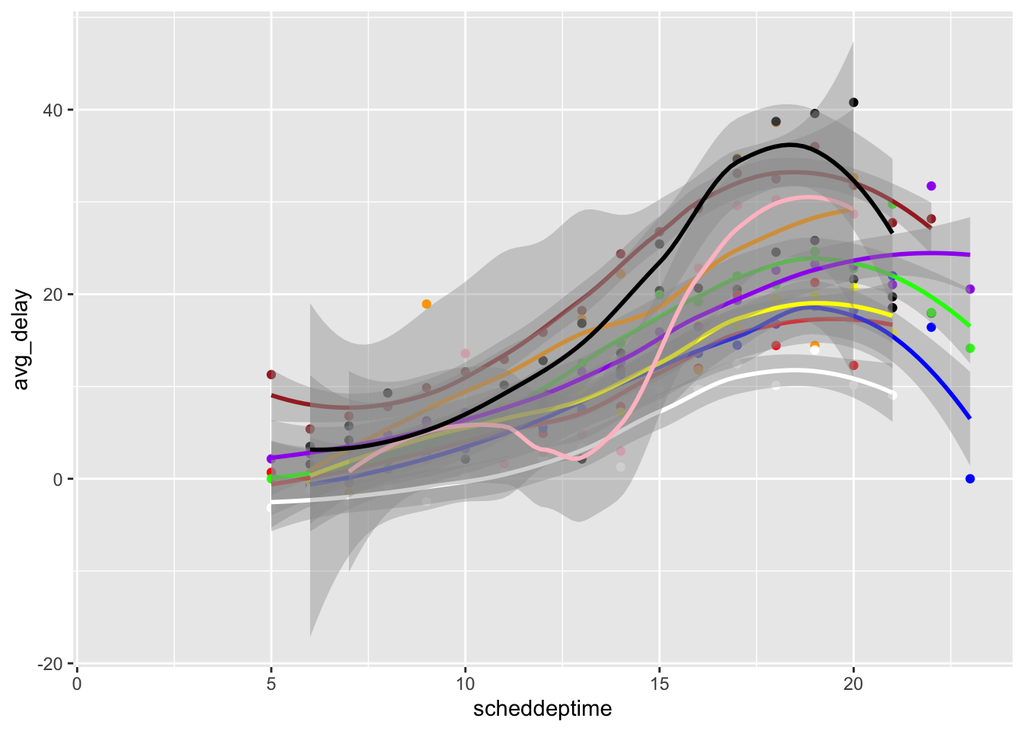

```r
Data9E = data %>% filter(carrier == "9E") %>% group_by(scheddeptime) %>% summarize(avg_delay = mean(dep_delay, na.rm = T), num = n())
DataAA = data %>% filter(carrier == "AA") %>% group_by(scheddeptime) %>% summarize(avg_delay = mean(dep_delay, na.rm = T), num = n())
DataB6 = data %>% filter(carrier == "B6") %>% group_by(scheddeptime) %>% summarize(avg_delay = mean(dep_delay, na.rm = T), num = n())
DataDL = data %>% filter(carrier == "DL") %>% group_by(scheddeptime) %>% summarize(avg_delay = mean(dep_delay, na.rm = T), num = n())
DataEV = data %>% filter(carrier == "EV") %>% group_by(scheddeptime) %>% summarize(avg_delay = mean(dep_delay, na.rm = T), num = n())
DataFL = data %>% filter(carrier == "FL") %>% group_by(scheddeptime) %>% summarize(avg_delay = mean(dep_delay, na.rm = T), num = n())
DataMQ = data %>% filter(carrier == "MQ") %>% group_by(scheddeptime) %>% summarize(avg_delay = mean(dep_delay, na.rm = T), num = n())
DataUA = data %>% filter(carrier == "UA") %>% group_by(scheddeptime) %>% summarize(avg_delay = mean(dep_delay, na.rm = T), num = n())
DataUS = data %>% filter(carrier == "US") %>% group_by(scheddeptime) %>% summarize(avg_delay = mean(dep_delay, na.rm = T), num = n())
DataVX = data %>% filter(carrier == "VX") %>% group_by(scheddeptime) %>% summarize(avg_delay = mean(dep_delay, na.rm = T), num = n())
DataWN = data %>% filter(carrier == "WN") %>% group_by(scheddeptime) %>% summarize(avg_delay = mean(dep_delay, na.rm = T), num = n())

p <- ggplot() + geom_point(data=Data9E, mapping = aes(x = scheddeptime,y = avg_delay)) +
          geom_point(data=DataAA, mapping = aes(x = scheddeptime,y = avg_delay), color = 'red') +
          geom_point(data=DataB6, mapping = aes(x = scheddeptime,y = avg_delay), color = 'green') +
          geom_point(data=DataDL, mapping = aes(x = scheddeptime,y = avg_delay), color = 'blue') +
          geom_point(data=DataEV, mapping = aes(x = scheddeptime,y = avg_delay), color = 'brown') +
          geom_point(data=DataFL, mapping = aes(x = scheddeptime,y = avg_delay), color = 'orange') +
          geom_point(data=DataMQ, mapping = aes(x = scheddeptime,y = avg_delay), color = 'yellow') +
          geom_point(data=DataUA, mapping = aes(x = scheddeptime,y = avg_delay), color = 'purple') +
          geom_point(data=DataUS, mapping = aes(x = scheddeptime,y = avg_delay), color = 'white') +
          geom_point(data=DataVX, mapping = aes(x = scheddeptime,y = avg_delay), color = 'pink') +
          geom_point(data=DataWN, mapping = aes(x = scheddeptime,y = avg_delay), color = 'black') +
          geom_smooth(data=DataAA, mapping = aes(x = scheddeptime,y = avg_delay), color = 'red') +
          geom_smooth(data=DataB6, mapping = aes(x = scheddeptime,y = avg_delay), color = 'green') +
          geom_smooth(data=DataDL, mapping = aes(x = scheddeptime,y = avg_delay), color = 'blue') +
          geom_smooth(data=DataEV, mapping = aes(x = scheddeptime,y = avg_delay), color = 'brown') +
          geom_smooth(data=DataFL, mapping = aes(x = scheddeptime,y = avg_delay), color = 'orange') +
          geom_smooth(data=DataMQ, mapping = aes(x = scheddeptime,y = avg_delay), color = 'yellow')+
          geom_smooth(data=DataUA, mapping = aes(x = scheddeptime,y = avg_delay), color = 'purple') +
          geom_smooth(data=DataUS, mapping = aes(x = scheddeptime,y = avg_delay), color = 'white') +
          geom_smooth(data=DataVX, mapping = aes(x = scheddeptime,y = avg_delay), color = 'pink') +
          geom_smooth(data=DataWN, mapping = aes(x = scheddeptime,y = avg_delay), color = 'black')
p
```

### Does time of year matter???

For the second part, I wanted to see if time of year mattered. So, I compared each departure time hour with the average delay, after filtering for each month. The resulting graph is below. From the graph, we can tell you will want to fly around September and October for shorter times all around. You will also want to avoid June and July, or fly as early as possible. It seems that the same pattern is consistent for all the months, but much more pronounced with much longer delays on average around 7 pm for June and July.

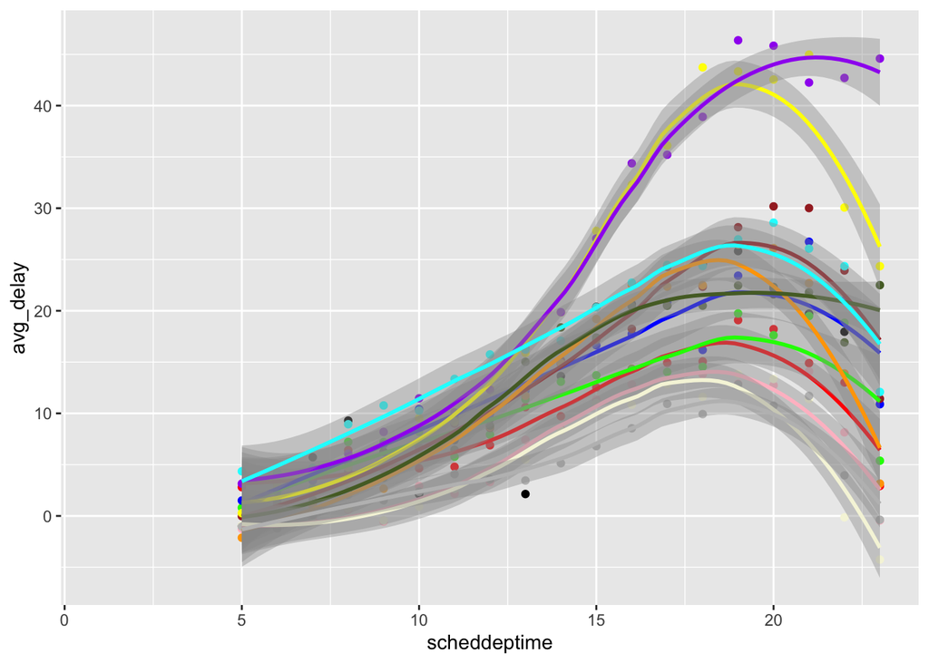

```r
DataJan = data %>% filter(month == 1) %>% group_by(scheddeptime) %>% summarize(avg_delay = mean(dep_delay, na.rm = T), num = n())
DataFeb = data %>% filter(month == 2) %>% group_by(scheddeptime) %>% summarize(avg_delay = mean(dep_delay, na.rm = T), num = n())
DataMar = data %>% filter(month == 3) %>% group_by(scheddeptime) %>% summarize(avg_delay = mean(dep_delay, na.rm = T), num = n())
DataApr = data %>% filter(month == 4) %>% group_by(scheddeptime) %>% summarize(avg_delay = mean(dep_delay, na.rm = T), num = n())
DataMay = data %>% filter(month == 5) %>% group_by(scheddeptime) %>% summarize(avg_delay = mean(dep_delay, na.rm = T), num = n())
DataJun = data %>% filter(month == 6) %>% group_by(scheddeptime) %>% summarize(avg_delay = mean(dep_delay, na.rm = T), num = n())
DataJul = data %>% filter(month == 7) %>% group_by(scheddeptime) %>% summarize(avg_delay = mean(dep_delay, na.rm = T), num = n())
DataAug = data %>% filter(month == 8) %>% group_by(scheddeptime) %>% summarize(avg_delay = mean(dep_delay, na.rm = T), num = n())
DataSep = data %>% filter(month == 9) %>% group_by(scheddeptime) %>% summarize(avg_delay = mean(dep_delay, na.rm = T), num = n())
DataOct = data %>% filter(month == 10) %>% group_by(scheddeptime) %>% summarize(avg_delay = mean(dep_delay, na.rm = T), num = n())
DataNov = data %>% filter(month == 11) %>% group_by(scheddeptime) %>% summarize(avg_delay = mean(dep_delay, na.rm = T), num = n())
DataDec = data %>% filter(month == 12) %>% group_by(scheddeptime) %>% summarize(avg_delay = mean(dep_delay, na.rm = T), num = n())

p <- ggplot() + geom_point(data=Data9E, mapping = aes(x = scheddeptime,y = avg_delay)) +
          geom_point(data=DataJan, mapping = aes(x = scheddeptime,y = avg_delay), color = 'red') +
          geom_point(data=DataFeb, mapping = aes(x = scheddeptime,y = avg_delay), color = 'green') +
          geom_point(data=DataMar, mapping = aes(x = scheddeptime,y = avg_delay), color = 'blue') +
          geom_point(data=DataApr, mapping = aes(x = scheddeptime,y = avg_delay), color = 'brown') +
          geom_point(data=DataMay, mapping = aes(x = scheddeptime,y = avg_delay), color = 'orange') +
          geom_point(data=DataJun, mapping = aes(x = scheddeptime,y = avg_delay), color = 'yellow') +
          geom_point(data=DataJul, mapping = aes(x = scheddeptime,y = avg_delay), color = 'purple') +
          geom_point(data=DataAug, mapping = aes(x = scheddeptime,y = avg_delay), color = 'darkolivegreen') +
          geom_point(data=DataSep, mapping = aes(x = scheddeptime,y = avg_delay), color = 'pink') +
          geom_point(data=DataOct, mapping = aes(x = scheddeptime,y = avg_delay), color = 'beige') +
          geom_point(data=DataNov, mapping = aes(x = scheddeptime,y = avg_delay), color = 'grey') +
          geom_point(data=DataDec, mapping = aes(x = scheddeptime,y = avg_delay), color = 'cyan') +
          geom_smooth(data=DataJan, mapping = aes(x = scheddeptime,y = avg_delay), color = 'red') +
          geom_smooth(data=DataFeb, mapping = aes(x = scheddeptime,y = avg_delay), color = 'green') +
          geom_smooth(data=DataMar, mapping = aes(x = scheddeptime,y = avg_delay), color = 'blue') +
          geom_smooth(data=DataApr, mapping = aes(x = scheddeptime,y = avg_delay), color = 'brown') +
          geom_smooth(data=DataMay, mapping = aes(x = scheddeptime,y = avg_delay), color = 'orange') +
          geom_smooth(data=DataJun, mapping = aes(x = scheddeptime,y = avg_delay), color = 'yellow') +
          geom_smooth(data=DataJul, mapping = aes(x = scheddeptime,y = avg_delay), color = 'purple') +
          geom_smooth(data=DataAug, mapping = aes(x = scheddeptime,y = avg_delay), color = 'darkolivegreen') +
          geom_smooth(data=DataSep, mapping = aes(x = scheddeptime,y = avg_delay), color = 'pink') +
          geom_smooth(data=DataOct, mapping = aes(x = scheddeptime,y = avg_delay), color = 'beige') +
          geom_smooth(data=DataNov, mapping = aes(x = scheddeptime,y = avg_delay), color = 'grey') +
          geom_smooth(data=DataDec, mapping = aes(x = scheddeptime,y = avg_delay), color = 'cyan')
p
```

##Does Flight Origin matter?

For the third part, I wanted to see if flight origin mattered in determining when to fly. It seems there is a very minor effect

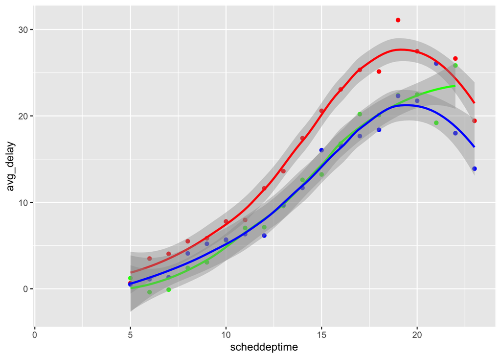

```r
DataEWR = data %>% filter(origin == "EWR") %>% group_by(scheddeptime) %>% summarize(avg_delay = mean(dep_delay, na.rm = T), num = n())
DataLGA = data %>% filter(origin == "LGA") %>% group_by(scheddeptime) %>% summarize(avg_delay = mean(dep_delay, na.rm = T), num = n())
DataJFK = data %>% filter(origin == "JFK") %>% group_by(scheddeptime) %>% summarize(avg_delay = mean(dep_delay, na.rm = T), num = n())

p <- ggplot() + geom_point(data=DataEWR, mapping = aes(x = scheddeptime,y = avg_delay), color = 'red') +
          geom_point(data=DataLGA, mapping = aes(x = scheddeptime,y = avg_delay), color = 'green') +
          geom_point(data=DataJFK, mapping = aes(x = scheddeptime,y = avg_delay), color = 'blue') +
          geom_smooth(data=DataEWR, mapping = aes(x = scheddeptime,y = avg_delay), color = 'red') +
          geom_smooth(data=DataLGA, mapping = aes(x = scheddeptime,y = avg_delay), color = 'green') +
          geom_smooth(data=DataJFK, mapping = aes(x = scheddeptime,y = avg_delay), color = 'blue')

p
```